# Class_movies_modul_9 (1)

## 4 Step-by-step K-means

In this step we take movie_x3 dataset using the scatter point and take the attribute of the crime movie and action movie comparisons and make the scatter plot and thenafter i take the random centroid for 3 cluster point and take bracket of (4,8),(9,6)and(9,9.5)and create modle and of the 3 cluster and make the kmeans model and their modellables and after that using upper centroide and kmeans classification make new color model of diffrent lables group and print the clusters.

```python
movie_x3.columns
```

```
Index(['act_movie', 'com_movie', 'cri_movie'], dtype='object')
```

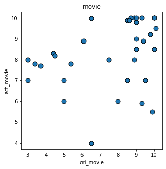

```python
fig = plt.figure(figsize=(5,5))

plt.scatter(movie_x3.cri_movie, movie_x3.act_movie, edgecolor = 'black', s = 80)
plt.title('movie')
plt.xlabel('cri_movie')
plt.ylabel('act_movie')
```

I take the three random centroide for three cluster for clustering.

```python
centroid1 = np.array([4,8])
centroid2 = np.array([9, 6])
centroid3 = np.array([9,9.5])
print(centroid1, centroid2, centroid3)
```

```
[4 8] [9 6] [9.  9.5]
```

using the random centroide make cricle use the centroid and adject the cluster on scatter plot.

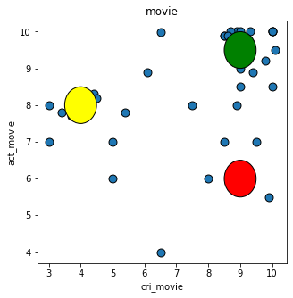

```python
fig = plt.figure(figsize=(5,5))

plt.scatter(movie_x3.cri_movie, movie_x3.act_movie, edgecolor = 'black', s = 80)
plt.title('movie')
plt.xlabel('cri_movie')
plt.ylabel('act_movie')
circle1 = plt.Circle(centroid1, radius=0.5, edgecolor = 'black', fc='yellow')
circle2 = plt.Circle(centroid2, radius=0.5, edgecolor = 'black', fc='red')
circle3 = plt.Circle(centroid3, radius=0.5, edgecolor = 'black', fc='green')
plt.gca().add_patch(circle1)
plt.gca().add_patch(circle2)
plt.gca().add_patch(circle3)
```

make the model for using the kmeans on based on the three cluster and create model lables.

```python
model = KMeans(n_clusters = 3)
model.fit(movie_x3)
```

```
KMeans(n_clusters=3)
```

```python
model.labels_
```

```
array([1, 0, 2, 0, 2, 1, 2, 1, 0, 1, 2, 1, 0, 1, 1, 1, 1, 0, 2, 1, 1, 0,
       1, 1, 1, 0, 0, 0, 2, 0, 1, 2, 2, 1, 1, 1])
```

```python
centroid1 = np.array([4,8])
centroid2 = np.array([9, 6])
centroid3 = np.array([9,9.5])
print(centroid1, centroid2, centroid3)
```

```
[4 8] [9 6] [9.  9.5]
```

use the upper scatter plot and help with the centroide and model lables create new kmeans classification and show the different group of yellow,blue and red and made the clusters.

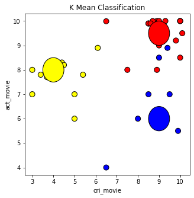

```python
fig = plt.figure(figsize=(5, 5))

colormap = np.array(['yellow', 'red', 'blue'])

plt.scatter(movie_x3.cri_movie, movie_x3.act_movie, c=colormap[model.labels_], edgecolor = 'black', s = 80)
plt.title('K Mean Classification')
plt.xlabel('cri_movie')
plt.ylabel('act_movie')
circle1 = plt.Circle(centroid1, radius=0.5, edgecolor = 'black', fc='yellow')
circle2 = plt.Circle(centroid2, radius=0.5, edgecolor = 'black', fc='blue')
circle3 = plt.Circle(centroid3, radius=0.5, edgecolor = 'black', fc='red')
plt.gca().add_patch(circle1)
plt.gca().add_patch(circle2)
plt.gca().add_patch(circle3)
```

```python
kmeans = KMeans(n_clusters=3)
```

```python
kmeans.fit(movie_x3)
```

```
KMeans(n_clusters=3)
```

```python
clusters = kmeans.cluster_centers_
print(clusters)
```

```
[[9.53833333 9.20555556 9.01666667]
 [6.97142857 7.32857143 9.08571429]
 [7.33636364 7.74545455 4.54545455]]
```